# Prediction Using Supervised ML

Mahlatsi Mashilo

2024-06-15

## GRIP Task 1

Here we will be predicting the percentage of a student on the no.of study hours. The aim is to use a supervised machine learning model(Simple Linear Regression) to perform the predictions

# ===========================================================

## Packages

```r
#install.packages('caTools')
#install.packages("Metrics", dependencies=TRUE)
library(Metrics)
library(caTools)
library(ggplot2)
theme_set(theme_classic())
```

# ===========================================================

## Data Importation

```r
data <- read.csv("student_scores.csv")
head(data)
```

```
##   Hours Scores
## 1   2.5     21
## 2   5.1     47
## 3   3.2     27
## 4   8.5     75
## 5   3.5     30
## 6   1.5     20
```

# ===========================================================

## Plots

here are some plots for data understanding

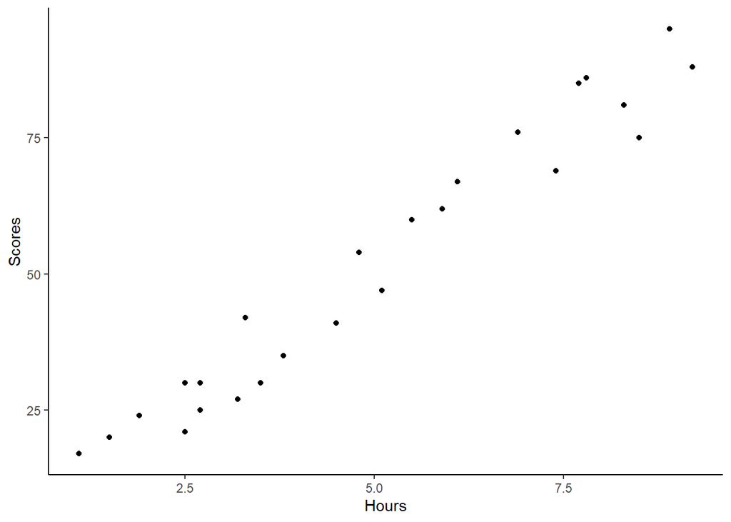

```r
ggplot(data,aes(x = Hours, y = Scores)) + geom_point()
```

### Observation From the plot we can see that the points show a relatively strong positive relationship with little to no points that we can classify as outliers. We can simply say that the Hours and Scores are directly proportional meaning the more hours you study, the higher the test score will be.

# ===========================================================

## Data Set Splitting

Lets split the data into training and testing sets.

```
##    Hours Scores
## 1    2.5     21
## 2    5.1     47
## 3    3.2     27
## 4    8.5     75
## 6    1.5     20
## 7    9.2     88
## 8    5.5     60
## 9    8.3     81
## 10   2.7     25
## 12   5.9     62
## 13   4.5     41
## 14   3.3     42
## 15   1.1     17
## 17   2.5     30
## 18   1.9     24
## 19   6.1     67
## 21   2.7     30
## 22   4.8     54
## 23   3.8     35
## 25   7.8     86
```

```
##    Hours Scores
## 5    3.5     30
## 11   7.7     85
## 16   8.9     95
## 20   7.4     69
## 24   6.9     76
```